# STAT 415 Lab 3

TYPE YOUR NAMES HERE

# 1 Introduction

In the handouts we have focused on inference for a population proportion. This lab will continue Lab 2 and cover inference for a population mean of a numerical variable. In particular, this lab covers:

- Predictive distributions for a numerical variable
- Continuous prior and posterior distributions for a population mean

As in Lab 2,this lab will make some simplifying assumptions. We’ll consider more realistic scenarios later.

**Important note regarding code:** We will cover code for performing and summarizing Bayesian analyses in much more detail throughout the course. Early in the course I have tried to keep the code as simple and bare bones as possible, especially with respect to plotting. There are certainly better ways to code, especially better plots that could be made. You are welcome to jazz it up (or tidyverse it up) if you want, but it’s certainly not required. The main goal for this lab is to understand the basic process.

# 2 Instructions

This RMarkdown file provides a template for you to fill in. **Read the file from start to finish, completing the parts as indicated.** **Some code is provided for you. Be sure to run this code, and make sure you understand what it’s doing.** Some blank “code chunks” are provided; you are welcome to add more (Code > Insert chunk or CTRL-ALT-I) as needed. There are also a few places where you should type text responses. Feel free to add additional text responses as necessary.

You can run individual code chunks using the play button. You can use objects defined in one chunk in others. Just keep in mind that chunks are evaluated in order. So if you call something x in one chunk, but redefine x as something else in another chunk, it’s essential that you evaluate the chunks in the proper order.

- click **Knit** and check to make sure that you have no errors and everything runs properly. (Fix any problems and redo this step until it works.)
- Make sure your type your name(s) at the top of the notebook where it says “Type your name(s) here”. If you worked in a team, you will submit a single notebook with both names; make sure both names are included
- Submit your completed files in Canvas.

You’ll need a few R packages, which you can install using `install.packages`

```r
library(ggplot2)
library(dplyr)
library(knitr)
library(janitor)

knitr::opts_chunk$set(
  echo = TRUE,
  warning = FALSE,
  message = FALSE
)
```

# 3 Estimating mean human body temperature: Prior predictive tuning

Assume body temperatures (degrees Fahrenheit) of *healthy adult humans* follow a Normal distribution with unknown mean $\theta$ and known standard deviation $\sigma=1$. We wish to estimate $\theta$, the population mean healthy human body temperature, based on sample data.  
Note: it’s unrealistic to assume the population standard deviation is known. We’ll consider the case of unknown standard deviation later.

In Lab 2 we used a grid approximation for the possible value of $\theta$. Now we’ll treat $\theta$ as a continuous random variable and assign it a continuous prior distribution.

We’ll assume the prior distribution of $\theta$ is a Normal distribution. We’ll assume a prior mean of 98.6 since that is what most “people on the street” would say is average human body temperature. But we’re not sure of what our prior SD should be, so we’ll use prior predictive tuning to determine a reasonable value.

Let’s start with a prior SD of 2, which is a fairly uninformative prior, assigning relative high prior probability to a wide range of values. For example, a 68% prior credible interval for $\theta$ based on this prior is [96.6, 100.6]; 95% is [94.6, 102.6].

**Exercise.** Use simulation to approximate the prior predictive distribution of body temperatures for a large sample of healthy adult humans. Make a histogram of the values. Explain why the simulation results suggest we might want to change our model.

Note: [lots of things influence body temperature, and there is a wide range of what is “normal”](https://www.webmd.com/first-aid/normal-body-temperature). But there are certainly body temperatures that would indicate a non-healthy human. For example, hypothermia occurs when body temperature is below 95 degrees F.

```r
### Type your code here. Feel free to add chunks as necessary
```

**TYPE YOUR RESPONSE HERE.**

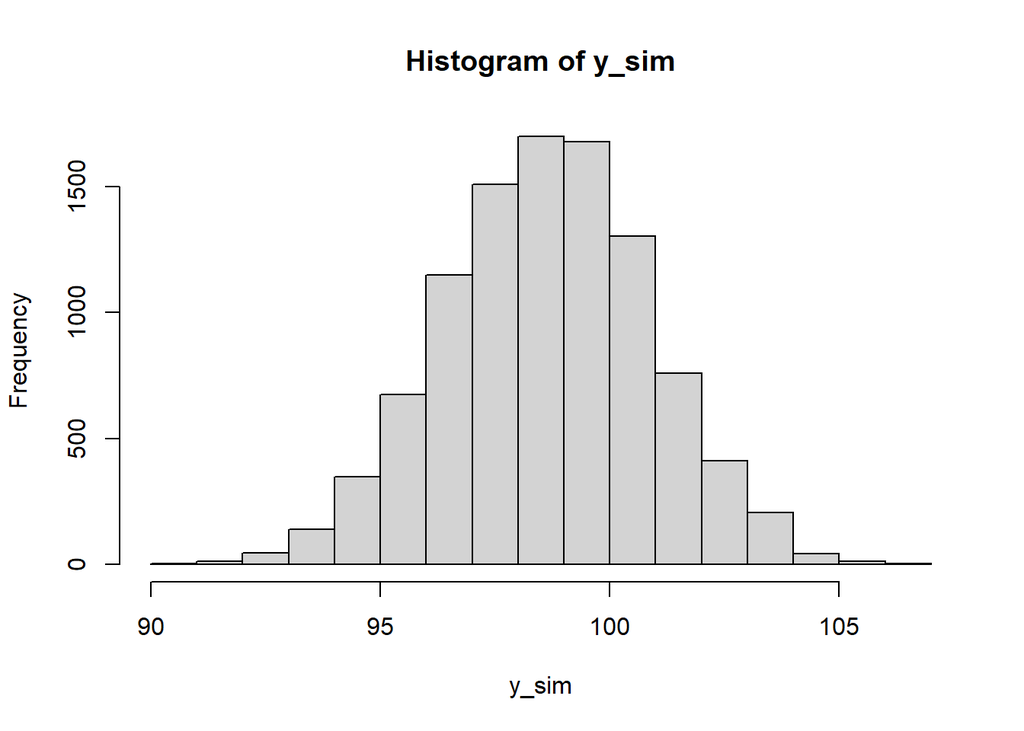

```r
n_sim = 10000

theta_sim = rnorm(n_sim, 98.6, 2)

sigma = 1

y_sim = rnorm(n_sim, theta_sim, sigma)

hist(y_sim)
```

Way too much probability in the tales. For example, according to this model, 5.5 percent of *healthy* humans have hypothermia.

A Bayesian model consists of both prior and likelihood. Inadequacies in the model could be due to prior, likelihood, or both. For now, we’ll just consider changing the prior, and more specifically just changing the prior SD.

**Exercise.** Choose another value for the prior SD and rerun the prior predictive simulation. Continue experimenting with different values of prior SD until you have what you think is a reasonable prior predictive distribution of healthy adult human body temperatures. There is no one right answer here, but explain your reasoning behind your final choice for the prior SD

You should try a few values of prior SD, but you only need to include the results for your final choice.

```r
### Type your code here. Feel free to add chunks as necessary
```

**TYPE YOUR RESPONSE HERE.**

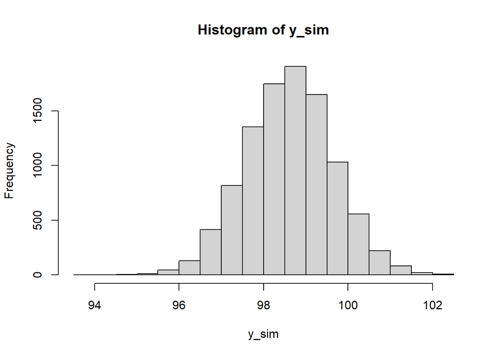

```r
n_sim = 10000

theta_sim = rnorm(n_sim, 98.6, 0.3)

sigma = 1

y_sim = rnorm(n_sim, theta_sim, sigma)

hist(y_sim)
```

Provides a more reasonable range of body temperatures. Still maybe a little too heavy in the tails, but it’s certainly an improvement.

# 4 Deriving the posterior distribution

Regardless of your answer to the previous part, assume a prior SD of 0.3. That is, assume the prior distribution of $\theta$ is a Normal distribution with mean 98.6 and standard deviation 0.3 (degrees Fahrenheit).

Also, recall that we’re assuming that body temperatures (degrees Fahrenheit) of *healthy adult humans* follow a Normal distribution with unknown mean $\theta$ and known standard deviation $\sigma=1$.

We’ll walk through the derivation of the posterior distribution given a few data points. Mind the **PAUSE**s; be sure to **PAUSE** and think about these questions before proceeding.

## 4.1 Prior distribution

First, we’ll write an expression for the prior distribution of $\theta$. **PAUSE** and try this now.

The prior distribution is represented by a continuous probability density function. Remember that in the prior distribution $\theta$ is treated as the variable. We’ll leave out constants (e.g., $1/\sqrt{2\pi}$) that won’t affect the *shape* of the prior
$$\pi(\theta) \propto \exp\left(-\frac{1}{2}\left(\frac{\theta - 98.6}{0.3}\right)^2\right)$$
This is a distribution on values of the parameter $\theta$.

## 4.2 Likelihood for a single observation

Suppose a single temperature value of 97.9 is observed. Write an expression for the likelihood function. **PAUSE** and try this now.

The likelihood follows from the assumption that body temperatures follows a Normal($\theta$, 1) distribution. The likelihood of the data $y=97.9$ is the Normal($\theta$, 1) density evaluated at 97.9, viewed as a function of $\theta$.
$$f(y = 97.9|\theta) \propto \exp\left(-\frac{1}{2}\left(\frac{97.9-\theta}{1}\right)^2\right)$$
**Careful!** In the prior distribution, $\theta$ plays the role of the random variable. In the likelihood, $\theta$ enters the picture as the *mean* of the measured variable (temperature); but the likelihood is a function of $\theta$.

## 4.3 Posterior distribution given a single observation

Write an expression for the posterior distribution of $\theta$ given a single temperature value of 97.9. **PAUSE** and try this now.

As always, posterior is proportional to likelihood times prior
$$\pi(\theta|y = 97.9) \propto \exp\left(-\frac{1}{2}\left(\frac{\theta - 98.6}{0.3}\right)^2\right)\exp\left(-\frac{1}{2}\left(\frac{97.9-\theta}{1}\right)^2\right)$$
After some algebra (e.g., completing the square), you can show that as a function of $\theta$ this expression represents a Normal distribution. We’ll provide more detail below.

## 4.4 Likelihood for two observations

Now consider the original Normal(98.6, 0.3) prior again. Determine the likelihood of observing temperatures of 97.9 and 97.5 in a random sample of size 2. **PAUSE** and try this now.

Assuming a random sample, the two temperature measurements are independent. So the likelihood of the pair (97.9, 97.5) is the product of the likelihood of each value.
$$f(y=(97.9, 97.5)|\theta) \propto \exp\left(-\frac{1}{2}\left(\frac{97.9-\theta}{1}\right)^2\right)\exp\left(-\frac{1}{2}\left(\frac{97.5-\theta}{1}\right)^2\right)$$

## 4.5 Posterior distribution given two observations

Write an expression for the posterior distribution of $\theta$ given temperature measurements of 97.9 and 97.5 in a random sample of size 2. **PAUSE** and try this now.

The following is a plot of prior, (scaled) likelihood, and posterior after the (97.9, 97.5) sample. Observe that the posterior resembles a Normal distribution.

Note: don’t worry too much about the following code. Some of the details just adjust the scales so that the three curves can be viewed on a single plot. Just focus on

- `dnorm(theta, 98.6, 0.3)` for the prior
- `dnorm(97.9, theta, sigma) * dnorm(97.5, theta, sigma)` for the likelihood
- `posterior = prior * likelihood` for the posterior

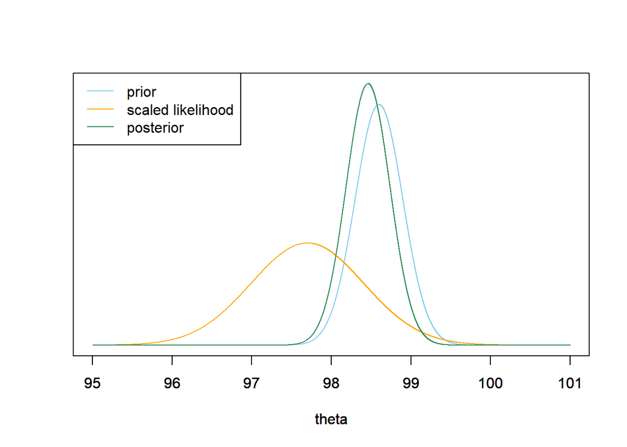

```r
delta = 0.0001
theta = seq(95, 101, delta)

# prior
prior = dnorm(theta, 98.6, 0.3)

# likelihood of (97.9, 97.5)
sigma = 1

likelihood = dnorm(97.9, theta, sigma) * dnorm(97.5, theta, sigma)
likelihood = likelihood / sum(likelihood) / delta # density scale

# posterior
posterior = prior * likelihood
posterior = posterior / sum(posterior) / delta # density scale

# plot
ymax = max(c(prior, likelihood, posterior))

plot(theta, prior, type='l', col='skyblue', xlim=range(theta), ylim=c(0, ymax), ylab='', yaxt='n')
par(new=T)
plot(theta, likelihood, type='l', col='orange', xlim=range(theta), ylim=c(0, ymax), ylab='',  yaxt='n')
par(new=T)
plot(theta, posterior, type='l', col='seagreen', xlim=range(theta), ylim=c(0, ymax), ylab='', yaxt='n')
legend("topleft", c("prior", "scaled likelihood", "posterior"), lty=1, col=c("skyblue", "orange", "seagreen"))
```

## 4.6 Likelihood of the sample mean

Consider the original prior again. Suppose that we take a random sample of two temperature measurements, but instead of observing the two individual values, we only observe that the sample mean is 97.7. Determine the likelihood of observing a sample mean of 97.7 in a random sample of size 2. **PAUSE** and try this now. Hint: if $\bar{Y}$ is the sample mean of $n$ values from a $N(\theta, \sigma)$ distribution, what is the distribution of $\bar{Y}$?

If $\bar{Y}$ is the sample mean of $n$ values from a $N(\theta, \sigma)$ distribution, then $\bar{Y}$ follows a $N(\theta, \sigma/\sqrt{n})$ distribution. To evaluate the likelihood of a sample mean of 97.7, evaluate the Normal($\theta$, $1/\sqrt{2}$) density at 97.7, viewed as a function of $\theta$.
$$f(\bar{y} = 97.7|\theta) \propto \exp\left(-\frac{1}{2}\left(\frac{97.7-\theta}{1/\sqrt{2}}\right)^2\right)$$

## 4.7 Posterior distribution given the sample mean

Write an expression for the posterior distribution of $\theta$ given a sample mean of 97.7 in a random sample of size 2. **PAUSE** and try this now.

The plot below illustrates the prior, scaled likelihood, and posterior given the sample mean of 97.7. Compare to the plot based on the (97.9, 97.5) above; the results are the same.

Note: Again, don’t worry about the details of the code. Just focus on:

- `dnorm(theta, 98.6, 0.3)` for the prior
- `dnorm(97.7, theta, sigma / sqrt(n))` for the likelihood
- `posterior = prior * likelihood` for the posterior
- posterior based on sample mean of 97.7 is same as based on full sample of (97.9, 97.5)

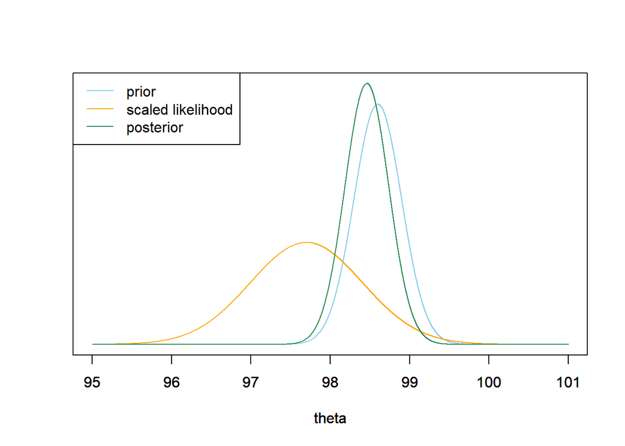

```r
delta = 0.0001
theta = seq(95, 101, delta)

# prior
prior = dnorm(theta, 98.6, 0.3)

# likelihood of sample mean of 97.7
sigma = 1

n = 2
ybar = 97.7

likelihood = dnorm(ybar, theta, sigma / sqrt(n))
likelihood = likelihood / sum(likelihood) / delta # density scale

# posterior
posterior = prior * likelihood
posterior = posterior / sum(posterior) / delta # density scale

# plot
ymax = max(c(prior, likelihood, posterior))

plot(theta, prior, type='l', col='skyblue', xlim=range(theta), ylim=c(0, ymax), ylab='', yaxt='n')
par(new=T)
plot(theta, likelihood, type='l', col='orange', xlim=range(theta), ylim=c(0, ymax), ylab='',  yaxt='n')
par(new=T)
plot(theta, posterior, type='l', col='seagreen', xlim=range(theta), ylim=c(0, ymax), ylab='', yaxt='n')
legend("topleft", c("prior", "scaled likelihood", "posterior"), lty=1, col=c("skyblue", "orange", "seagreen"))
```

It is often not necessary to know all the individual data values to evaluate the *shape* of the likelihood as a function of the parameter $\theta$, but rather simply the values of a few summary statistics.  
For example, when estimating the population mean of a Normal distribution with known standard deviation $\sigma$, it is sufficient to know the sample mean for the purposes of evaluating the shape of the likelihood of the observed data under different potential values of the population mean.

# 5 Normal-Normal model

In the previous example we saw that if the values of the measured variable (temperature) follow a Normal distribution with mean $\theta$ (and known SD) and the prior for $\theta$ follows a Normal distribution, then the posterior distribution for $\theta$ given the data also follows a Normal distribution. Performing some algebra on the product of the Normal prior and the Normal likelihood, we can show the following.

**Normal-Normal model.** Consider a measured variable $Y$ which, given $\theta$, follows a Normal$(\theta, \sigma)$ distribution, with $\sigma$ known. Let $\bar{y}$ be the sample mean for a random sample of size $n$. Suppose $\theta$ has a Normal$(\mu_0, \tau_0)$ prior distribution. Then the posterior distribution of $\theta$ given $\bar{y}$ is the Normal$(\mu_n, \tau_n)$ distribution, where

$$\begin{align*}
\text{posterior precision:} & &\frac{1}{\tau_n^2} & = \frac{1}{\tau_0^2} + \frac{n}{\sigma^2}\\
\text{posterior mean:} & & \mu_n & = \left(\frac{\frac{1}{\tau_0^2} }{\frac{1}{\tau_0^2} + \frac{n}{\sigma^2}}\right)\mu_0 + \left(\frac{\frac{n}{\sigma^2}}{ \frac{1}{\tau_0^2} + \frac{n}{\sigma^2}}\right)\bar{y}\\
\end{align*}$$

That is, Normal distributions form a *conjugate prior* family for a Normal likelihood.

The **precision** of a Normal distribution is the reciprocal of its variance. If $Y$ follows a Normal$(\theta, \sigma)$ distribution, the precision in a single measurement of $Y$ is $1/\sigma^2$. For a random sample of $n$ values of the variable $Y$, the sample mean $\bar{Y}$ follows a Normal distribution with standard deviation $\sigma/\sqrt{n}$ and precision $n/\sigma^2$. That is, the precision in $n$ independent data values is $n$ times the precision in a single value.

The posterior distribution is a compromise between prior and likelihood. For the Normal-Normal model, there is an intuitive interpretation of this compromise.

- The posterior precision is the sum of the prior precision and the data precision.
- The posterior mean is a weighted average of the prior mean and the sample mean, with weights proportional to the precisions.

|  | Prior | Data (Sample Mean) | Posterior |
| --- | --- | --- | --- |
| Precision | $\frac{1}{\tau_0^2}$ | $\frac{n}{\sigma^2}$ | $\frac{1}{\tau_n^2} = \frac{1}{\tau_0^2}+\frac{n}{\sigma^2}$ |
| SD | $\tau_0$ | $\frac{\sigma}{\sqrt{n}}$ | $\tau_n$ |
| Mean | $\mu_0$ | $\bar{y}$ | $\mu_n = \left(\frac{\frac{1}{\tau_0^2} }{\frac{1}{\tau_0^2} + \frac{n}{\sigma^2}}\right)\mu_0 + \left(\frac{\frac{n}{\sigma^2}}{ \frac{1}{\tau_0^2} + \frac{n}{\sigma^2}}\right)\bar{y}$ |

Try this [applet which illustrates the Normal-Normal model](https://shiny.stat.ncsu.edu/bjreich/NormalNormal/).

In the previous example:

- $\mu_0 = 98.6$, the prior mean
- $\tau_0 = 0.3$, the prior SD
- $\bar{y} = 97.7$, the sample mean
- $n=2$, the sample size

The code below just plugs the numbers into the above Normal-Normal model formulas.

```r
# prior
mu0 = 98.6
tau0 = 0.3

# data
sigma = 1
n = 2
ybar = 97.7

# posterior
tau_n = 1 / sqrt(n / sigma ^ 2 + 1 / tau0 ^ 2)
mu_n = mu0 * (1 / tau0 ^ 2) / (1 / tau_n ^ 2) + ybar * (n / sigma ^ 2) / (1 / tau_n ^ 2)

df = data.frame(c("Precision", "SD", "Mean"),
                c(1 / tau0 ^ 2, tau0, mu0),
                c(n / sigma ^ 2, sigma / sqrt(n), ybar),
                c(1 / tau_n ^ 2, tau_n, mu_n))

kable(df, digits = 3, align = 'r',
      col.names = c("", "Prior", "Data (Sample Mean)", "Posterior"))
```

|  | Prior | Data (Sample Mean) | Posterior |
| --- | --- | --- | --- |
| Precision | 11.111 | 2.000 | 13.111 |
| SD | 0.300 | 0.707 | 0.276 |
| Mean | 98.600 | 97.700 | 98.463 |

Therefore, the posterior distribution of $\theta$ is Normal with posterior mean 98.46 and posterior SD 0.276, which seems consistent with the plot above.

## 5.1 Exercises

Recall the assumptions:

- body temperatures (degrees Fahrenheit) of *healthy adult humans* follow a Normal distribution with unknown mean $\theta$ and known standard deviation $\sigma=1$.
- the prior distribution of $\theta$ is a Normal distribution with mean 98.6 and standard deviation 0.3 (degrees Fahrenheit).

In a recent study[^1], the sample mean body temperature in a sample of 208 healthy adults was 97.7 degrees F.

In the previous lab you used grid approximation to find the posterior distribution. Now you will use the Normal-Normal model.

1. Use the Normal-Normal model to find the posterior distribution of $\theta$.
2. Make a plot of the prior, the scaled likelihood and the posterior. How do the results for the $n=208$ sample compare to the $n=2$ sample?
3. Compute and interpret central 50%, 80%, and 98% posterior credible intervals for $\theta$.
4. Compute the posterior probability that $\theta$ is less than 98.6.

```r
### Type your code here. Feel free to add chunks as necessary
```

**TYPE YOUR RESPONSE HERE.**

```r
# prior
mu0 = 98.6
tau0 = 0.3

# data
sigma = 1
n = 208
ybar = 97.7

# posterior
tau_n = 1 / sqrt(n / sigma ^ 2 + 1 / tau0 ^ 2)
mu_n = mu0 * (1 / tau0 ^ 2) / (1 / tau_n ^ 2) + ybar * (n / sigma ^ 2) / (1 / tau_n ^ 2)

df = data.frame(c("Precision", "SD", "Mean"),
                c(1 / tau0 ^ 2, tau0, mu0),
                c(n / sigma ^ 2, sigma / sqrt(n), ybar),
                c(1 / tau_n ^ 2, tau_n, mu_n))

kable(df, digits = 3, align = 'r',
      col.names = c("", "Prior", "Data (Sample Mean)", "Posterior"))
```

|  | Prior | Data (Sample Mean) | Posterior |
| --- | --- | --- | --- |
| Precision | 11.111 | 208.000 | 219.111 |
| SD | 0.300 | 0.069 | 0.068 |
| Mean | 98.600 | 97.700 | 97.746 |

The posterior distribution of $\theta$ is Normal with posterior mean 97.7 and posterior SD 0.068 degrees F.

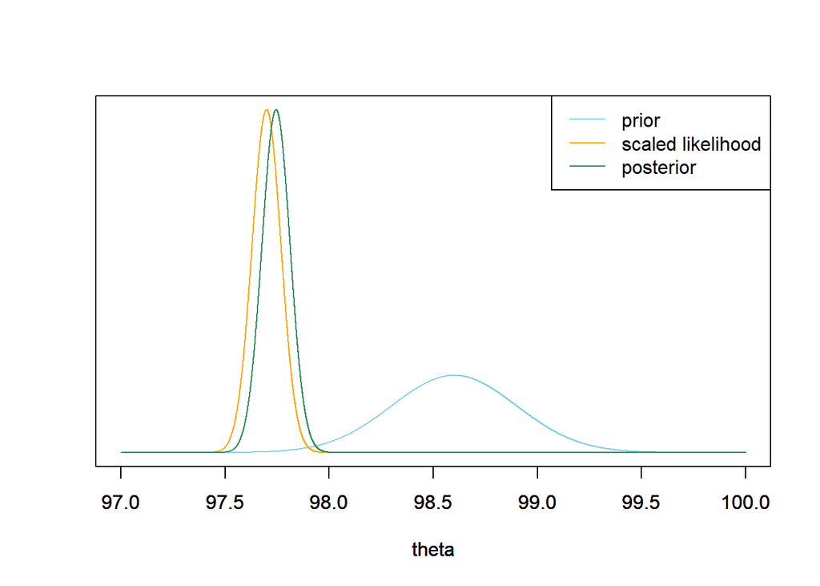

```r
theta = seq(97, 100, 0.0001) # the grid is just for plotting

# prior
prior = dnorm(theta, mu0, tau0)

# likelihood
likelihood = dnorm(ybar, theta, sigma / sqrt(n))

# posterior
posterior = dnorm(theta, mu_n, tau_n)

# plot
ymax = max(c(prior, posterior))
scaled_likelihood = likelihood * ymax / max(likelihood)

plot(theta, prior, type='l', col='skyblue', xlim=range(theta), ylim=c(0, ymax), ylab='', yaxt='n')
par(new=T)
plot(theta, scaled_likelihood, type='l', col='orange', xlim=range(theta), ylim=c(0, ymax), ylab='',  yaxt='n')
par(new=T)
plot(theta, posterior, type='l', col='seagreen', xlim=range(theta), ylim=c(0, ymax), ylab='', yaxt='n')
legend("topright", c("prior", "scaled likelihood", "posterior"), lty=1, col=c("skyblue", "orange", "seagreen"))
```

We see that the prior has a lot less influence with the sample of size 208 than with the samples size 2. Also, we see that the likelihood zeros out a lot of the values that we initially gave high prior plausibility to.

```r
qnorm(c(0.25, 0.75), mu_n, tau_n)
```

```
## [1] 97.70007 97.79121
```

```r
qnorm(c(0.10, 0.90), mu_n, tau_n)
```

```
## [1] 97.65906 97.83222
```

```r
qnorm(c(0.01, 0.99), mu_n, tau_n)
```

```
## [1] 97.58848 97.90280
```

There is basically 100% posterior probability that mean human body temperatures is less than 98.6 degrees F. We would be willing to bet almost any amount of money on this.

Of course, all of our conclusions assume that the sample is reasonably representative of healthy human body temperatures.

# 6 Posterior predictive checking

Continuing the previous exercises, is the model from above reasonable? We can use the posterior predictive distribution to simulate what samples of size $n=208$ might look like and compare to the observed sample data.

First let’s look at the sample data on 208 temperature measurements. Notice that the sample mean is 97.7 and the sample SD is 1 (consistent with the assumed population SD of $\sigma = 1$.)

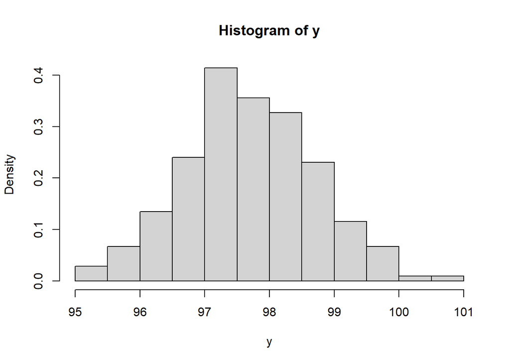

```r
data = read.csv("temperature.csv")
y = data$temperature

hist(y, freq = FALSE)
```

```r
summary(y)
```

```
##    Min. 1st Qu.  Median    Mean 3rd Qu.    Max.
##   95.05   97.06   97.60   97.70   98.32  100.88
```

```r
sd(y)
```

```
## [1] 0.9999203
```

```r
n = length(y)
ybar = mean(y)
```

How would you use posterior predictive simulation to simulate a possible sample of size 208 under the model?

**PAUSE** to try this now.

1. Simulate a value of $\theta$ from the posterior distribution
2. Given the values of $\theta$, simulate a sample of size 208 from a Normal distribution with mean $\theta$ and SD $\sigma = 1$.

Then we repeat this process many times and compare the simulated samples to the observed data.

The plot below displays a histogram of the observed sample data, along with a density curve for each of 100 simulated samples from the posterior predictive distribution. (Old note: The posterior distribution of $\theta$ below is based on the sample of size 2. The posterior distribution based on the sample of size 2 does *not* seem to provide an adequate model.)

**The posterior is now based on the full sample of size 208.**

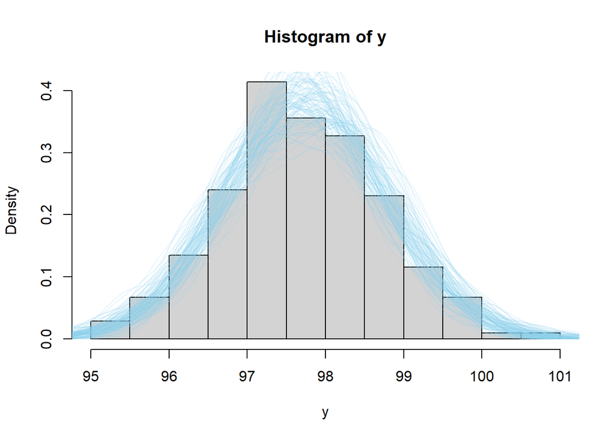

```r
# plot the observed data
hist(y, freq = FALSE) # observed data

# number of samples to simulate
n_samples = 100

# simulate thetas from posterior
theta = rnorm(n_samples, mu_n, tau_n)

# simulate samples
for (r in 1:n_samples){

  # simulate values from N(theta, sigma) distribution
  y_sim = rnorm(n, theta[r], sigma)

  # add plot of simulated sample to histogram
  lines(density(y_sim),
        col = rgb(135, 206, 235, max = 255, alpha = 50))
}
```

## 6.1 Exercises.

1. Rerun the posterior predictive simulation using the posterior distribution based on the full sample of size $n=208$. Reproduce a plot like the one above.
2. Does the model seem reasonable in light of the posterior predictive simulation?
3. Use simulation to find a 95% posterior prediction interval.
4. Write a clearly worded sentence interpreting the prediction interval from the previous part in context.

```r
### Type your code here. Feel free to add chunks as necessary
```

**TYPE YOUR RESPONSE HERE.**

See above for plot. The model seems reasonable. Simulated samples match up with observed data fairly well.

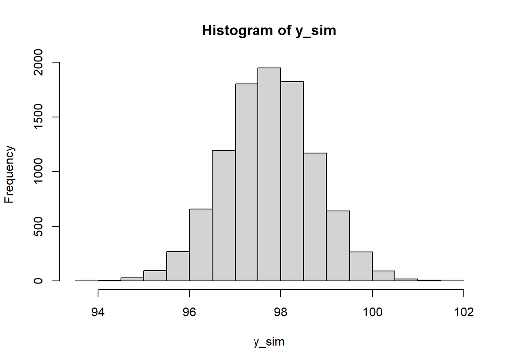

```r
n_sim = 10000

theta_sim = rnorm(n_sim, mu_n, tau_n)

sigma = 1

y_sim = rnorm(n_sim, theta_sim, sigma)

hist(y_sim)
```

```r
quantile(y_sim, c(0.025, 0.975))
```

```
##     2.5%    97.5%
## 95.79281 99.67599
```

There is posterior predictive probability of 95% that a randomly selected healthy adult human body temperature is between 95.8 and 99.7 degrees F. Roughly, we predict that 95% of healthy human adults have body temperatures between 95.8 and 99.7 degrees F.

# 7 Application: Birthweights

Suppose that birthweights (grams) of human babies follow a Normal distribution with unknown mean $\theta$ and known SD $\sigma = 600$. (1 pound $\approx$ 454 grams.)

1. Assume a Normal prior distribution for $\theta$. Identify what you think are reasonable values for the prior mean and the prior SD. Explain your reasoning. Include a prior predictive simulation as part of your justification.
2. The following summarizes data on a random sample[^2] of 1000 live births in the U.S. in 2001.

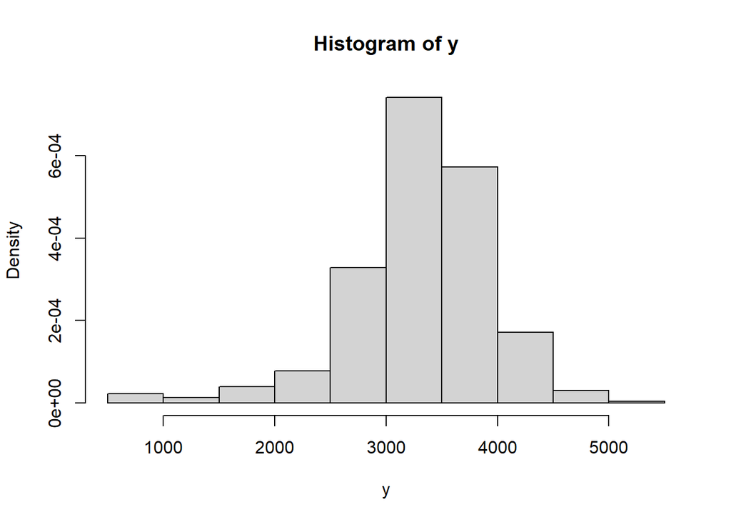

   ```r
   data = read.csv("birthweight.csv")
   y = data$birthweight

   hist(y, freq = FALSE)
   ```

   ```r
   summary(y)
   ```

   ```
   ##    Min. 1st Qu.  Median    Mean 3rd Qu.    Max.
   ##     595    3005    3350    3315    3714    5500
   ```

   ```r
   sd(y)
   ```

   ```
   ## [1] 631.3303
   ```

   ```r
   n = length(y)
   ybar = mean(y)

   sigma = 600 # assumed
   ```

3. Find the posterior distribution of $\theta$ given the sample data.
4. Find and interpret 50%, 80%, 98% central posterior credible interval for $\theta$.
5. Use simulation to compute a 95% prediction interval.
6. Write a clearly worded sentence interpreting the prediction interval from the previous part in context.
7. Use posterior predictive checking to simulate what samples of size 1000 might look like under the posterior model. Include a plot comparing simulated samples to the observed data. Do you notice any problems with the fit of the model? If so, what assumption of the model appears to be violated?

```r
### Type your code here. Feel free to add chunks as necessary
```

**TYPE YOUR RESPONSE HERE.**

## 7.1 Prior predictive distribution

We’ll try a prior distribution which places most of its probability on mean birthweight being between 7 and 8 pounds: prior mean of 3400 grams (around 7.5 pounds) and a prior SD of 100 grams (about 0.22 pounds).

```r
# prior
mu0 = 3400
tau0 = 100
```

Here is the prior predictive distribution.

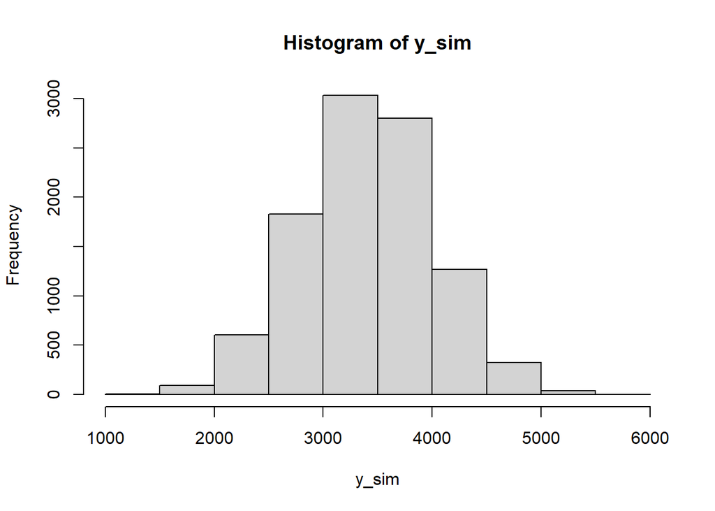

```r
n_sim = 10000

theta_sim = rnorm(n_sim, mu0, tau0)

y_sim = rnorm(n_sim, theta_sim, sigma)

hist(y_sim)
```

```r
quantile(y_sim, c(0.025, 0.975))
```

```
##     2.5%    97.5%
## 2199.622 4620.321
```

Prior model predicts that about 95% of babies weigh between about 5 and 10 pounds, which seems fairly reasonable. It’s not obviously wrong (no negative birthweights, no 25 pounds babies).

## 7.2 Posterior distribution

```r
# posterior
tau_n = 1 / sqrt(n / sigma ^ 2 + 1 / tau0 ^ 2)
mu_n = mu0 * (1 / tau0 ^ 2) / (1 / tau_n ^ 2) + ybar * (n / sigma ^ 2) / (1 / tau_n ^ 2)

df = data.frame(c("Precision", "SD", "Mean"),
                c(1 / tau0 ^ 2, tau0, mu0),
                c(n / sigma ^ 2, sigma / sqrt(n), ybar),
                c(1 / tau_n ^ 2, tau_n, mu_n))

kable(df, digits = 3, align = 'r',
      col.names = c("", "Prior", "Data (Sample Mean)", "Posterior"))
```

|  | Prior | Data (Sample Mean) | Posterior |
| --- | --- | --- | --- |
| Precision | 0 | 0.003 | 0.003 |
| SD | 100 | 18.974 | 18.641 |
| Mean | 3400 | 3314.959 | 3317.914 |

The posterior distribution of mean birthweight $\theta$ is Normal with posterior mean 3317.9 and posterior SD 18.641 grams.

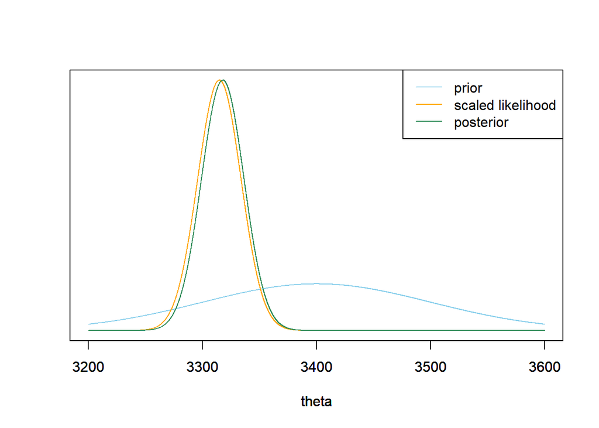

```r
theta = seq(3200, 3600, 0.01) # the grid is just for plotting

# prior
prior = dnorm(theta, mu0, tau0)

# likelihood
likelihood = dnorm(ybar, theta, sigma / sqrt(n))

# posterior
posterior = dnorm(theta, mu_n, tau_n)

# plot
ymax = max(c(prior, posterior))
scaled_likelihood = likelihood * ymax / max(likelihood)

plot(theta, prior, type='l', col='skyblue', xlim=range(theta), ylim=c(0, ymax), ylab='', yaxt='n')
par(new=T)
plot(theta, scaled_likelihood, type='l', col='orange', xlim=range(theta), ylim=c(0, ymax), ylab='',  yaxt='n')
par(new=T)
plot(theta, posterior, type='l', col='seagreen', xlim=range(theta), ylim=c(0, ymax), ylab='', yaxt='n')
legend("topright", c("prior", "scaled likelihood", "posterior"), lty=1, col=c("skyblue", "orange", "seagreen"))
```

## 7.3 Posterior credible intervals

```r
qnorm(c(0.25, 0.75), mu_n, tau_n)
```

```
## [1] 3305.341 3330.487
```

```r
qnorm(c(0.10, 0.90), mu_n, tau_n)
```

```
## [1] 3294.025 3341.804
```

```r
qnorm(c(0.01, 0.99), mu_n, tau_n)
```

```
## [1] 3274.548 3361.280
```

Of course, all of our conclusions assume that the sample is reasonably representative and the model is correct - but see posterior predictive checking below.

## 7.4 Posterior prediction interval

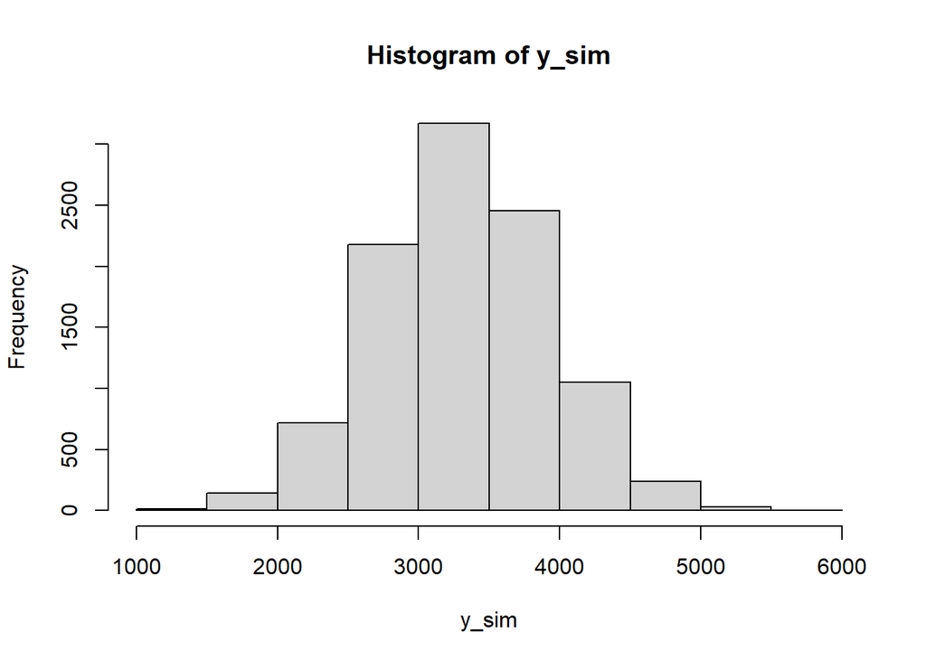

```r
n_sim = 10000

theta_sim = rnorm(n_sim, mu_n, tau_n)

y_sim = rnorm(n_sim, theta_sim, sigma)

hist(y_sim)
```

```r
quantile(y_sim, c(0.025, 0.975))
```

```
##     2.5%    97.5%
## 2141.620 4521.641
```

```r
quantile(y_sim, c(0.005, 0.995))
```

```
##     0.5%    99.5%
## 1761.126 4894.368
```

There is posterior predictive probability of 95% that a randomly selected newborn baby weighs between 2141.6 and 4521.6 grams. Roughly, we predict that 95% of babies have birthweights between 2141.6 and 4521.6 grams.

## 7.5 Posterior predictive checking

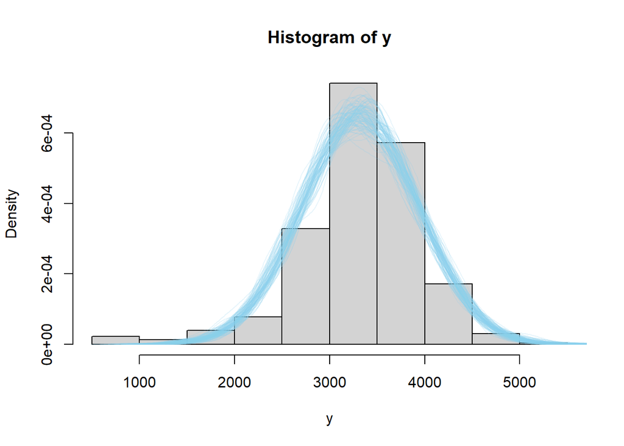

```r
# plot the observed data
hist(y, freq = FALSE) # observed data

# number of samples to simulate
n_samples = 100

# simulate thetas from posterior
theta = rnorm(n_samples, mu_n, tau_n)

# simulate samples
for (r in 1:n_samples){

  # simulate values from N(theta, sigma) distribution
  y_sim = rnorm(n, theta[r], sigma)

  # add plot of simulated sample to histogram
  lines(density(y_sim),
        col = rgb(135, 206, 235, max = 255, alpha = 50))
}
```

The histogram indicates that the model isn’t the greatest. For example, consider the 99% prediction interval. We predict that only 1% of birthweights would be outside this interval, but in the sample 2.6 percent of birthweights were outside the interval. While not a large difference in absolute magnitude, we are observing 3 times more values in the tails than we would expect if birthweights followed a Normal distribution. So we have some evidence that a Normal model might not be the best model for birthweights of all live births as it doesn’t properly account for extreme birthweights. (Of course, it could be true that a Normal model is ok, but our assumed standard deviation of $\sigma$ is wrong. But if we tried to increase $\sigma$ to compensate for the extreme values, then the fit would get worse in the middle of the distribution.)

A Normal likelihood doesn’t account for the extremes well enough, and we’ll see how to deal with this later.

# 8 Reflection

1. Write a few sentences summarizing one important concept you have learned in this lab
2. What is (at least) one question that you still have?

**TYPE YOUR RESPONSE HERE.**

[^1]: [Source](https://www.ncbi.nlm.nih.gov/pmc/articles/PMC6258625/) and a [related article](https://www.scientificamerican.com/article/are-human-body-temperatures-cooling-down/).
[^2]: There are about 4 million live births in the U.S. per year. The data is available at the [CDC website](https://www.cdc.gov/nchs/data_access/vitalstatsonline.htm).